# An Introduction to Statistical Learning (2013)

Chapter Code

by Brian Hassett

# Chapter 5 Resampling Methods

This notebook is a rough outline of **Chapter 5** of **An Introduction to Statistical Learning** (James et al. (2013)[^1]).

The authors do not provide code for the analysis or figures used throughout each chapter. They do however provide access to some of the data. This notebook uses the data to recreate *some* of the analysis and figures from the chapter.

## Setup

```r
library(ISLR)
library(tidyverse)
library(boot)
library(patchwork)
theme_set(theme_bw())

# Given a filename, return the filepath. Default folder is the `data` folder in the current working directory.
get_path <- function(filename) {
  str_c(getwd(), "data", filename, sep = "/")
}

# Colors:
ISLR_blue <- "#176FC0"
ISLR_brown <- "#94340E"
```

View the `Auto` data:

```r
Auto
```

|  | mpg | cylinders | displacement | horsepower | weight | acceleration | year | origin | name |
| --- | --- | --- | --- | --- | --- | --- | --- | --- | --- |
| 1 | 18.0 | 8 | 307.0 | 130 | 3504 | 12.0 | 70 | 1 | chevrolet chevelle malibu |
| 2 | 15.0 | 8 | 350.0 | 165 | 3693 | 11.5 | 70 | 1 | buick skylark 320 |
| 3 | 18.0 | 8 | 318.0 | 150 | 3436 | 11.0 | 70 | 1 | plymouth satellite |
| 4 | 16.0 | 8 | 304.0 | 150 | 3433 | 12.0 | 70 | 1 | amc rebel sst |
| 5 | 17.0 | 8 | 302.0 | 140 | 3449 | 10.5 | 70 | 1 | ford torino |
| 6 | 15.0 | 8 | 429.0 | 198 | 4341 | 10.0 | 70 | 1 | ford galaxie 500 |
| 7 | 14.0 | 8 | 454.0 | 220 | 4354 | 9.0 | 70 | 1 | chevrolet impala |
| 8 | 14.0 | 8 | 440.0 | 215 | 4312 | 8.5 | 70 | 1 | plymouth fury iii |
| 9 | 14.0 | 8 | 455.0 | 225 | 4425 | 10.0 | 70 | 1 | pontiac catalina |
| 10 | 15.0 | 8 | 390.0 | 190 | 3850 | 8.5 | 70 | 1 | amc ambassador dpl |

[output cut: 382 more lines]

### FIGURE 5.2

The right-hand panel doesn’t look as smooth as the book but this is probably due to the splits used.

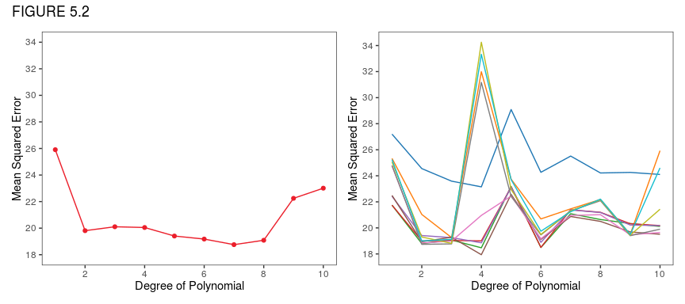

```r
# Left panel:
set.seed(1)
test <- sample(nrow(Auto), nrow(Auto)/2)
degrees <- 1:10

mods <- map(degrees, function(a) {
  mod <- lm(mpg ~ poly(horsepower, a), data = Auto[-test, ])
})

MSE <- map_dbl(mods, function(mod) {
  preds <- predict(mod, newdata = Auto[test, ])
  MSE <-  mean((preds - Auto$mpg[test])^2)
  return(MSE)
})

# Need to make the RHS before we can add the scales

# Right panel:
set.seed(5) # depending on the seed the plots looke very differen, and not very like the text
k = 10 # no. of iterations

MSE_k <- matrix(0, nrow = k, ncol = length(degrees)) # MSE for each iteration

for(i in 1:k) {
  test <- sample(nrow(Auto), nrow(Auto)/2)
  mods <- map(degrees, function(a) {
    mod <- lm(mpg ~ poly(horsepower, a), data = Auto[-test, ])
  })

  MSE_k[i, ] <- map_dbl(mods, function(mod) {
    preds <- predict(mod, newdata = Auto[test, ])
    MSE <-  mean((preds - Auto$mpg[test])^2)
    return(MSE)
  })
}

p2 <- data.frame(degree = degrees, MSE_k) %>%
  pivot_longer(cols = X1:X10, names_to = "iteration", values_to = "MSE") %>%
  ggplot() +
  geom_line(aes(degree, MSE, color = iteration),
            show.legend = FALSE) +
  scale_x_continuous(name = "Degree of Polynomial",
                     breaks = seq(2, 10, by = 2)) +
  scale_y_continuous(name = "Mean Squared Error",
                     breaks = seq(round(min(MSE_k)), round(max(MSE_k)), by = 2)) +
  ggsci::scale_color_d3() +
  theme(panel.grid = element_blank())

colors_5.2 <- c("red" = "#EB1F2B")

p1 <- tibble(
  degree = degrees,
  MSE = MSE
  ) %>%
  ggplot(aes(degree, MSE)) +
  geom_point(color = colors_5.2["red"]) +
  geom_line(color = colors_5.2["red"]) +
  scale_x_continuous(name = "Degree of Polynomial",
                     breaks = seq(2, 10, by = 2)) +
  scale_y_continuous(name = "Mean Squared Error",
                     breaks = seq(round(min(MSE_k)), round(max(MSE_k)), by = 2),
                     limits = c(round(min(MSE_k)), round(max(MSE_k)))) +
  theme(panel.grid = element_blank())

p1 + p2 + plot_annotation(title = "FIGURE 5.2")
```

## 5.1 Cross-Validation

### FIGURE 5.4

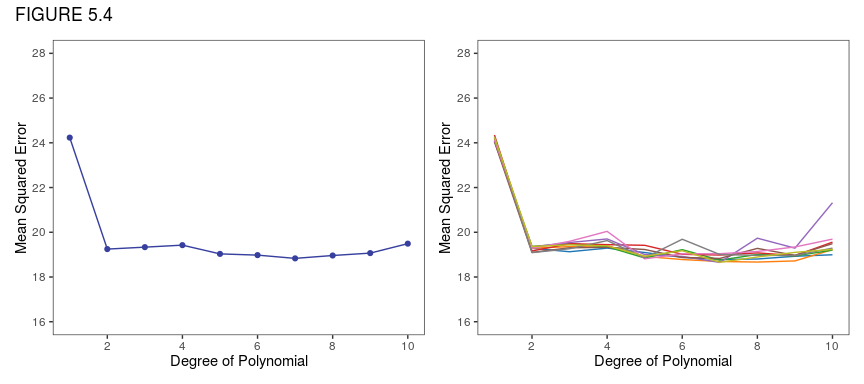

```r
colors_5.4 <- c("blue" = "#37409E")

# Left panel:
set.seed(1)
d <- 10
cv_error <- rep(0, d)

for(i in 1:d) {
  mod <- glm(mpg ~ poly(horsepower, i), data = Auto)
  cv_mod <- cv.glm(Auto, mod)
  cv_error[i] <- cv_mod$delta[1]
}

# Need to make the RHS before we can add the scales

# Right panel:
set.seed(1)
iterations <- 9
d <- 10
k <- 10

cv_errors <- matrix(0, ncol = d, nrow = iterations)

for(i in 1:iterations) {
  for(j in 1:d) {
    mod <- glm(mpg ~ poly(horsepower, j), data = Auto)
    cv_mod <- cv.glm(Auto, mod, K = k)
    cv_errors[i, j] <- cv_mod$delta[1]
  }
}

p1 <- tibble(
  d = 1:d,
  cv_error
) %>%
  ggplot(aes(d, cv_error)) +
  geom_point(color = colors_5.4["blue"]) +
  geom_line(color = colors_5.4["blue"]) +
  labs(x = "Degree of Polynomial", y = "Mean Squared Error") +
  scale_x_continuous(breaks = seq(2, 10, by = 2)) +
  scale_y_continuous(breaks = seq(16, 28, by = 2),
                     limits = c(16, 28)) +
  theme(panel.grid = element_blank())

p2 <- data.frame(iteration = 1:iterations, cv_errors) %>%
  pivot_longer(cols = X1:X10, names_to = "degree", values_to = "MSE") %>%
  mutate(degree = str_replace(degree, "X", ""),
         degree = as.numeric(degree),
         iteration = factor(iteration)) %>%
  ggplot(aes(degree, MSE, color = iteration)) +
  geom_line(show.legend = FALSE) +
  labs(x = "Degree of Polynomial", y = "Mean Squared Error") +
  scale_x_continuous(breaks = seq(2, 10, by = 2)) +
  scale_y_continuous(breaks = seq(16, 28, by = 2),
                     limits = c(16, 28)) +
  ggsci::scale_color_d3() +
  theme(panel.grid = element_blank())

p1 + p2 + plot_annotation(title = "FIGURE 5.4")
```

## 5.2 The Bootstrap

The `Portfolio` data set only has 100 observations, but this is associated with this problem. The data set is only later mentioned in the lab. It can be used for creating the bootstrap distribution of $\alpha$ (blue plots) in FIGURE 5.10. Since we don’t have the population data and I don’t know how to generate data with a given covariance I can’t do the orange plots.

View `Portfolio` data:

```r
Portfolio
```

| X | Y |
| --- | --- |
| -0.89525089 | -0.23492353 |
| -1.56245433 | -0.88517599 |
| -0.41708988 | 0.27188802 |
| 1.04435573 | -0.73419750 |
| -0.31556841 | 0.84198343 |
| -1.73712385 | -2.03719104 |
| 1.96641316 | 1.45295666 |
| 2.15286790 | -0.43413863 |
| -0.08120803 | 1.45080850 |
| -0.89178179 | 0.82101623 |

[output cut: 90 more lines]

### FIGURE 5.9

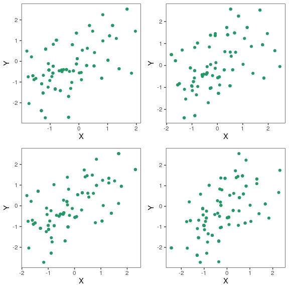

```r
colors_5.9 <- c("green" = "#249968")

bootstrap_sample <- function(data) {
  n <- nrow(data)
  sample <- sample(1:n, n, replace = TRUE)
  return(data[sample, ])
}

G <- vector("list", 4)

set.seed(1)
for(i in 1:4) {
  sample <- bootstrap_sample(Portfolio)
  G[[i]] <- ggplot(sample) +
    geom_point(aes(X, Y),
               color = colors_5.9["green"]) +
    theme(panel.grid = element_blank())
}

cowplot::plot_grid(plotlist = G, nrow = 2)
```

### FIGURE 5.10

(Can only do the bootstrap distribution)

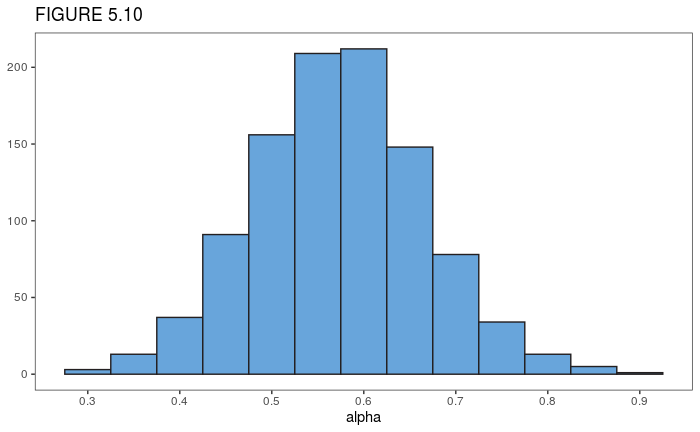

```r
colors_5.10 <- c("blue" = "#68A5DB",
                "orange" = "#D99411",
                "grey" = "#231F20")
alpha <- rep(0, 1000)

set.seed(1)
for(i in 1:1000) {
  sample <- bootstrap_sample(Portfolio)
  var.X <- var(sample$X)
  var.Y <- var(sample$Y)
  var.XY <- cov(sample$X, sample$Y)
  alpha[i] <- (var.Y - var.XY)/(var.X + var.Y - 2*var.XY)
}

tibble(alpha) %>%
  ggplot() +
  geom_histogram(aes(alpha),
                 binwidth = 0.05,
                 fill = colors_5.10["blue"],
                 color = colors_5.10["grey"]) +
  labs(y = NULL, title = "FIGURE 5.10") +
  scale_x_continuous(breaks = seq(0.3, 0.9, by = 0.1)) +
  theme(panel.grid = element_blank())
```

[^1]: James G, Witten D, Hastie T, Tibshirani R (2013). *An Introduction to Statistical Learning: with Applications in R*. Springer, 1st edition.